# Optimization

Wenxuan Zhang

2023-03-20

### Linear Programming

Object function & saturation curve are both linear

### Resource Constraint

- Product A 20 resource and Product B need 12
- Only 1800 resource available per day

### Time Constraint

- Both product require a production time of 1/15 hour
- A working day has a total of 8 hours

```r
library(lpSolve)
object.in <- c(25,20)
const.mat <- matrix(c(20,12,1/15,1/15),nrow = 2, byrow = TRUE)
const.rhs <- c(1800,8)
const.dir <- c("<=","<=")
optimum <- lp(direction = "max", object.in,
              const.mat,const.dir,const.rhs)

optimum$solution
```

```
## [1] 45 75
```

```r
optimum$objval
```

```
## [1] 2625
```

### Quadratic Programming

Object function is quadratic and constraint are linear

#### One Dimensional Non-Linear Programming

Golden Section Search can be used to solve one-dimensional non-linear problems

##### Basic Steps:

- Golden Ratio Defined as 0.618
- Pick an Interval A,b containing the optimum
- Evaludate f(x1) at x1 = a + (0.382)*(b-a) vs f(x2) at x2 = a + 0.618*(b-a)
- if f(x1) < f(x2), continue the search in the interval[a,x1] else [x2, b]

###### example

```r
f <- function(x)(print(x)-1/3)^2
xmin <- optimize(f, interval = c(0,1),tol =0.001)
```

```
## [1] 0.381966
## [1] 0.618034
## [1] 0.236068
## [1] 0.3333333
## [1] 0.333
## [1] 0.3336667
## [1] 0.3333333
```

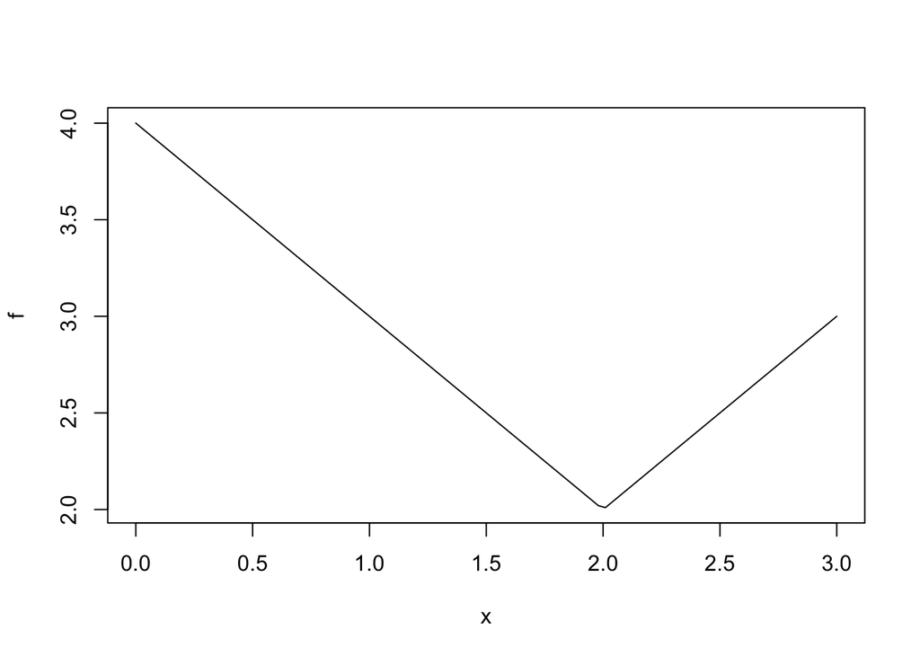

```r
#example 2: non-differentiable
f <- function(x) return(abs(x-2)+2*abs(x=1))
xmin <- optimize(f, interval = c(0,3),tol =0.001)

plot(f,0,3)
```

#### Non-Linear Multi-Dimensional Programming

```r
library(optimx)
#optimx(par,fn, gr = Null, Hess= Null, lower = inf,
#       upper = inf, method = '', itnmax = Null,...)
```

Multiple optimization algorithm possible: * Gradient based * Hessian based * Non-gradient based: golden section search, nelder-mead * if constraint was provided, “L-BFGS-B” is used

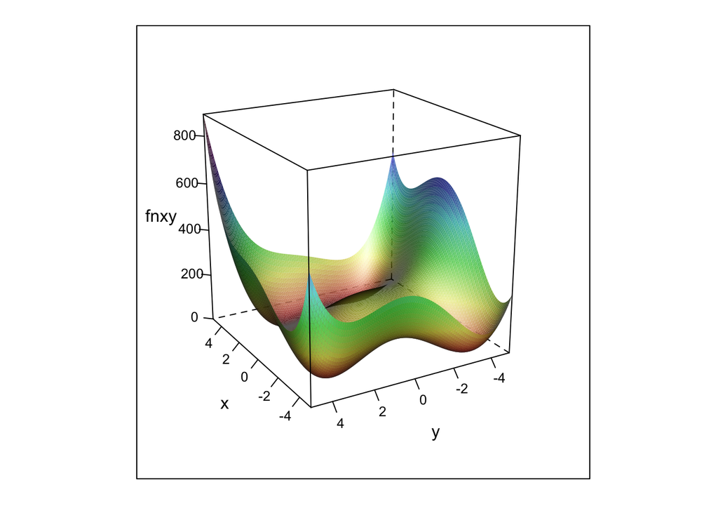

```r
# Himmelblau's function
fn <- function(para){
 matrix.A <- matrix(para, ncol = 2)
 x <- matrix.A[,1]
 y <- matrix.A[,2]
 f.x <- (x^2 + y -11)^2 + (x+y^2-7)^2
 return(f.x)
}

xy <- as.matrix(expand.grid(seq(-5,5,length = 101),
                            seq(-5,5, length = 101)))
colnames(xy) <- c("x","y")
df <- data.frame(fnxy = fn(xy),xy)

library(lattice)
wireframe(fnxy ~ x*y, data = df, shade = TRUE,
          drape = FALSE, scale = list(arrows=FALSE),
          screen = list(z = -240, x = -70, y =0))
```

#### Gradient-Free Method: Nelder-Mead

- Gradient information comes from an approximation of Hessian Matrix No guaranteed conversion, especially problematic if tayler expansion does not fit well.

```r
library(optimx)
fn <- function(x){
  return(log2(x+1))
}
par <- c(1)
optimx(par,fn, method  = 'Nelder-Mead')
```

```
##             p1 value fevals gevals niter convcode kkt1 kkt2 xtime
## Nelder-Mead -1   -53    211     NA    NA       10   NA   NA 0.002
```

```r
optimx(par, fn, method = 'CG')
```

```
##    p1         value fevals gevals niter convcode kkt1 kkt2 xtime
## CG NA 8.988466e+307     NA     NA    NA     9999   NA   NA     0
```

```r
optimx(par,fn, method = 'BFGS')
```

```
##      p1         value fevals gevals niter convcode kkt1 kkt2 xtime
## BFGS NA 8.988466e+307     NA     NA    NA     9999   NA   NA 0.001
```

```r
optimx(par,fn,method=c("Nelder-Mead","CG","BFGS","spg","nlm"))
```

```
##                     p1          value fevals gevals niter convcode kkt1 kkt2
## Nelder-Mead -1.0000000  -5.300000e+01    211     NA    NA       10   NA   NA
## CG                  NA  8.988466e+307     NA     NA    NA     9999   NA   NA
## BFGS                NA  8.988466e+307     NA     NA    NA     9999   NA   NA
## spg                 NA  8.988466e+307     NA     NA    NA     9999   NA   NA
## nlm         -0.9999991  -2.016338e+01     NA     NA    26        0   NA   NA
##             xtime
## Nelder-Mead 0.002
## CG          0.001
## BFGS        0.001
## spg         0.000
## nlm         0.004
```

```r
#-1 should be the optimal value to minimize this target
```

### R Optimization Infrastructure

```r
#ROI_available_solvers()

#install.packages('ROI.plugin.glpk')
#install.packages('ROI.plugin.quadprog')
#install.packages('ROI.plugin.symphony')
library(ROI)
library(ROI.plugin.glpk)


library(ROI.plugin.glpk)
lp <- OP(objective = c(2,4,4),
         L_constraint(
           L = matrix(c(3,2,1,4,1,3,2,2,2),nrow =3),
                      dir = c("<=","<=","<="),
                      rhs = c(60,40,80))
           ,maximum = TRUE)

sol <- ROI_solve(lp,solver = 'glpk')

#Solve quadratic problems with linear constraints

library(ROI.plugin.quadprog)
qp <- OP(Q_objective(Q = diag(1,3),
                     L = c(0,-5,0)),
         L_constraint(
           L = matrix(c(-4,-3,0,2,1,0,0,-2,1),ncol = 3,
                      byrow = TRUE),
           dir = rep (">=",3),
           rhs = c(-8,2,0)
         )
         )

sol <- ROI_solve(qp, solver = 'quadprog')
```

### Application in Stats

LASSO regression

```r
n <- 100
x1 <- rnorm(n)
x2 <- rnorm(n)
y <- 1 + x1 + x2 + rnorm(n)
X <- cbind (rep(1,n),x1,x2)
r <- lm(y~ x1 + x2)
library(quadprog)
s <- solve.QP(t(X) %*% X, t(y)%*%X, matrix(nr = 3, nc = 0),numeric(),0)
coef(r)
```

```
## (Intercept)          x1          x2
##    1.023172    1.039217    1.151398
```

```r
s$solution
```

```
## [1] 1.023172 1.039217 1.151398
```

```r
# with constraints => yes, you could set constriant >=
s1 <- solve.QP(t(X) %*% X, t(y)%*%X, cbind(diag(1,3)),c(0.5,1.5,2),0)
s1$solution
```

```
## [1] 1.171022 1.500000 2.000000
```

```r
s2 <- solve.QP(t(X) %*% X, t(y)%*%X, cbind(diag(1,3),-diag(1,3)),c(0.5,0.5,0.5,-0.8,-1.1,-1.2),0)
s2$solution
```

```
## [1] 0.800000 1.009566 1.133046
```

### Optimization inside Quantile Regression

```r
n <- 101
x <- rlnorm(n)
library(lpSolve)

A1 <- cbind(diag(2*n),0)
A2 <- cbind(diag(n),-diag(n),1)

r <- lp('min',
        c(rep(1, 2*n),0),
        rbind(A1,A2),
        c(rep (">=",2*n),rep("=",n)),
        c(rep(0, 2*n),x))
tail(r$solution,1)
```

```
## [1] 0.8835516
```

```r
median(x)
```

```
## [1] 0.8835516
```

Introducing tau = .3 allows to calculate quantile regression

```r
require(lpSolve)
tau <- .3
n <- 100
x1 <-rnorm(n)
x2 <- rnorm(n)
y <- 1 + x1 + x2 + rnorm(n)
X <- cbind(rep(1,n),x1,x2)
A1 <- cbind(diag(2*n),0,0,0)
A2 <- cbind(diag(n),-diag(n),X)

r <- lp("min",c(rep(tau,n),
                rep(1-tau,n),0,0,0),
        rbind(A1,A2),
        c(rep(">=",2*n),rep ("=",n)),
        c(rep(0,2*n),y)
    )

tail(r$solution,3)
```

```
## [1] 0.1725398 0.8444317 1.0086881
```

```r
library(quantreg)
rq(y~x1+x2, tau = 0.5)
```

```
## Call:
## rq(formula = y ~ x1 + x2, tau = 0.5)
##
## Coefficients:
## (Intercept)          x1          x2
##   0.9127520   0.8015468   1.0754576
##
## Degrees of freedom: 100 total; 97 residual
```

https://web.stanford.edu/class/archive/cs/cs109/cs109.1166/pdfs/40%20LogisticRegression.pdf

https://web.stanford.edu/~jurafsky/slp3/5.pdf

https://rpubs.com/dnuttle/ml-logistic-cost-func_derivative

https://www.baeldung.com/cs/gradient-descent-logistic-regression

How inscart deliver in time? https://www.youtube.com/watch?v=JvIzB3hULCo

https://www.youtube.com/watch?v=Gtz8ca_4hVg

### Logistic Regression

Logistic regression is the baseline model for classification problems. It is one of the generalized linear model. Instead of trying to get the relationship between Y and X, generalized linear models explore the relationship between Y and f(X).

The f(x) of logistic regression is the sigmod funtion.
$$Y = 1/(1+ e(-\beta X))$$
. And the model **form** is if Y = 0
$$P(Y|X) =
1/(1+e(-\beta X)$$
if Y = 0
$$P(Y|X)
= 1- 1/(1+e(-beta X))$$
Thus the formula can be written as

$$P(Y|X) = (1/1+e(-\beta X))^{Y} + (1-
1/(1+e(-\beta X))^{(1-Y)})$$

When I first learned the logistic regression, I was wondering, why do we choose the sigmoid function as the link funtion? Here are a couple reason.

1. Sigmoid function could transform value between (-Inf, +Inf) to [0,,1],which is a perfect fit for probability.
2. Sigmoif function got some very good math property:
- $$1 - f(x) = f(-x)$$
- $$d(f(x)) = f(x)*(1-f(x))*x$$

These property made it easier for future calculation.

The loss function for linear regression **(y-xb)^2**. For logistic regression, we use log likelihood, which equals $\sum Xi*P(Xi)$

$$y(log(1/(1+e(-\beta X)))) +
(1-y)*(1-1/(1+e(-\beta X)))$$
To get a solution for $\beta$, we use the **gradient descent** method. The gradient of loss function is
$$y/f(x) - (1-y)/(1-f(x)* d(fx)$$
$$\frac{y}{f(x)}-\frac{(1-y)}{(1-f(x))*f(x)}(1-f(x))*x$$
$$\frac{(y-f(x))}{f(x)*(1-f(x))}*f(x)(1-f(x))*x$$
$$(y-f(x))*x$$
##### Logistic Regression

```r
mydata <- read.csv("https://stats.idre.ucla.edu/stat/data/binary.csv")
# admit 1 then admitted 0 then do not
# gre score
# gpa
# rank (1,2,3,4) 4 different tier
head(mydata)
```

```
##   admit gre  gpa rank
## 1     0 380 3.61    3
## 2     1 660 3.67    3
## 3     1 800 4.00    1
## 4     1 640 3.19    4
## 5     0 520 2.93    4
## 6     1 760 3.00    2
```

```r
# can we use linear regression
lmodel <- lm(admit~.,data = mydata)
summary(lmodel)
```

```
##
## Call:
## lm(formula = admit ~ ., data = mydata)
##
## Residuals:
##     Min      1Q  Median      3Q     Max
## -0.6617 -0.3417 -0.1947  0.5061  0.9556
##
## Coefficients:
##               Estimate Std. Error t value Pr(>|t|)
## (Intercept) -0.1824127  0.2169695  -0.841   0.4010
## gre          0.0004424  0.0002101   2.106   0.0358 *
## gpa          0.1510402  0.0633854   2.383   0.0176 *
## rank        -0.1095019  0.0237617  -4.608 5.48e-06 ***
## ---
## Signif. codes:  0 '***' 0.001 '**' 0.01 '*' 0.05 '.' 0.1 ' ' 1
##
## Residual standard error: 0.4448 on 396 degrees of freedom
## Multiple R-squared:  0.09601,    Adjusted R-squared:  0.08916
## F-statistic: 14.02 on 3 and 396 DF,  p-value: 1.054e-08
```

```r
# intercept not meaningful, higher the rank harder to admit, higher gre & gpa will better to admit
# R^2 0.09

xtabs(~admit + rank, data = mydata)
```

```
##      rank
## admit  1  2  3  4
##     0 28 97 93 55
##     1 33 54 28 12
```

```r
mylogit <- glm(admit ~ gre + gpa + rank, data = mydata, family = "binomial")
summary(mylogit)
```

```
##
## Call:
## glm(formula = admit ~ gre + gpa + rank, family = "binomial",
##     data = mydata)
##
## Deviance Residuals:
##     Min       1Q   Median       3Q      Max
## -1.5802  -0.8848  -0.6382   1.1575   2.1732
##
## Coefficients:
##              Estimate Std. Error z value Pr(>|z|)
## (Intercept) -3.449548   1.132846  -3.045  0.00233 **
## gre          0.002294   0.001092   2.101  0.03564 *
## gpa          0.777014   0.327484   2.373  0.01766 *
## rank        -0.560031   0.127137  -4.405 1.06e-05 ***
## ---
## Signif. codes:  0 '***' 0.001 '**' 0.01 '*' 0.05 '.' 0.1 ' ' 1
##
## (Dispersion parameter for binomial family taken to be 1)
##
##     Null deviance: 499.98  on 399  degrees of freedom
## Residual deviance: 459.44  on 396  degrees of freedom
## AIC: 467.44
##
## Number of Fisher Scoring iterations: 4
```

```r
confint(mylogit)
```

```
##                     2.5 %       97.5 %
## (Intercept) -5.7109591680 -1.260314066
## gre          0.0001715446  0.004461385
## gpa          0.1415710585  1.428341503
## rank        -0.8149612229 -0.315479733
```

```r
#wald.test(b = coef(mylogit), Sigma = vcov(mylogit), Terms = 4:6)
exp(coef(mylogit))
```

```
## (Intercept)         gre         gpa        rank
##  0.03175998  1.00229659  2.17496718  0.57119114
```

```r
pred <- ifelse(predict(mylogit,data = mydata,type = "response")>0.34,1,0)

eval_data <- data.frame(pred = pred, actual= mydata$admit)
eval_metric <- xtabs(~actual+pred, data = eval_data)
accuracy <- sum(eval_metric[col(eval_metric)==row(eval_metric)])/sum(eval_metric)
print(paste(round(accuracy,3)*100,'% of prediction is right',sep =""))
```

```
## [1] "65.7% of prediction is right"
```

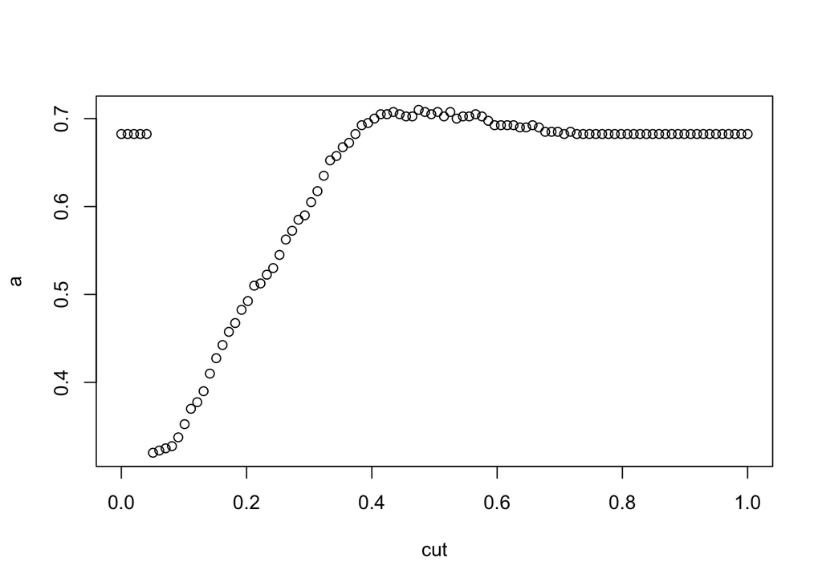

```r
cut <- seq(0,1,length=100)

getacc<-function(cut,mydata){
  met <- c()
  for (i in (1:length(cut))){
    pred <- ifelse(predict(mylogit,data = mydata,type = "response")>cut[i],1,0)
    eval_data <- data.frame(pred = pred, actual= mydata$admit)
    eval_metric <- xtabs(~actual+pred, data = eval_data)
    accuracy <- sum(eval_metric[col(eval_metric)==row(eval_metric)])/sum(eval_metric)
    met <- c(met,accuracy)
  }
  return(met)
}

a<-getacc(cut,mydata)
plot(cut,a)
```

```r
#70% of chance it is right
```

```r
# understand coef and make a prediction

coef_logit <- coef(mylogit)
X <- cbind(rep(1,dim(mydata)[1]),mydata[,c('gre','gpa','rank')])

link<- rowSums(X[1,] * coef_logit)
response <- 1/(1+exp(-link))
print(response)
```

```
##         1
## 0.1895527
```

```r
predict(mylogit,mydata[1,],type = 'response')
```

```
##         1
## 0.1895527
```

```r
predict(mylogit,mydata[1,],type = 'link')
```

```
##         1
## -1.452919
```

```r
#estimate coef by gradient
# start
sigmoid <- function(z)
{
g <- 1/(1+exp(-z))
return(g)
}

X <- as.matrix(mydata[,c(2,3,4)])
#Add ones to X
X <- cbind(rep(1,nrow(X)),X)
#Response variable
Y <- as.matrix(mydata$admit)

cost <- function(theta)
{
m <- nrow(X)
g <- sigmoid(X%*%theta)
J <- (1/m)*sum((-Y*log(g)) - ((1-Y)*log(1-g)))
return(J)
}

initial_theta <- rep(0,ncol(X))
#Cost at inital theta
cost(initial_theta)
```

```
## [1] 0.6931472
```

```r
theta_optim <- optim(par=initial_theta,fn=cost)
#set theta
theta <- theta_optim$par
#cost at optimal value of the theta
theta_optim$value
```

```
## [1] 0.5743022
```

```r
print(theta)
```

```
## [1] -3.44845274  0.00229386  0.77681115 -0.56015927
```

```r
print(coef_logit)
```

```
## (Intercept)         gre         gpa        rank
## -3.44954840  0.00229396  0.77701357 -0.56003139
```

```r
prob <- sigmoid(as.matrix(cbind(1,mydata[1,c(2,3,4)]))%*%theta)
print(prob)
```

```
##        [,1]
## 1 0.1895441
```

```r
predict(mylogit,data = mydata[c(1),],type = 'response')[1]
```

```
##         1
## 0.1895527
```

Gradient Descent Implementation https://www.r-bloggers.com/2013/12/logistic-regression-with-r-step-by-step-implementation-part-2/ https://theautomatic.net/2018/10/02/how-to-build-a-logistic-regression-model-from-scratch-in-r/

```r
theta0<-matrix(rep(0,4),ncol = 1)
alpha <- 0.001
y <- mydata$admit
x0 <- rep(a,dim(mydata)[1])
X <- cbind(x0,mydata[,c(2,3,4)])


sigmoid = function(z){
 1 / (1 + exp(-z))
}

grad = function(X, y, theta){
  X = as.matrix(X)
 m = nrow(X)
 hx = sigmoid(X %*% theta)
 (1/m) * (t(X) %*% (hx - y))
}

maxinteration = 100000
for (i in 1:maxinteration){
 theta1 = theta - alpha * grad(X, y, theta)
 if(sum(abs(theta1 - theta))/length(theta)<0.001) break
 thetha = theta1
}
print(theta)
```

```
## [1] -3.44845274  0.00229386  0.77681115 -0.56015927
```

```r
print(coef(mylogit))
```

```
## (Intercept)         gre         gpa        rank
## -3.44954840  0.00229396  0.77701357 -0.56003139
```

##### Optimization with objective function with exponential term

```r
if(FALSE){
library(CVXR)
a <- 7
b <- 0.3
M=1000
 # is a given vector of 1-D data

x <- Variable(1)
nominator <- (1-x)
#denominator <- (1/((a^(1-x))-(b^(1-x))))

denominator <- 1/(exp(log(a)*(1-x)) - exp(log(b)*(1-x)))

obj <- (-x*sum(log(x)) + M*log(nominator/denominator)) # change M to the length of X_i later
constr <- list(x>=0)
prob <- Problem(Maximize(obj), constr)
result <- solve(prob)
alpha_hat <- result$getValue(x)
}
```

Data Science Topics https://datascience.oneoffcoder.com/autograd-logistic-regression-gradient-descent.html

https://nhorton.people.amherst.edu/ips9/IPS_09_Ch14.pdf

https://rpubs.com/junworks/Understanding-Logistic-Regression-from-Scratch

https://stackoverflow.com/questions/64707768/how-to-solve-an-objective-function-having-an-exponential-term-with-a-different-b

https://docs.mosek.com/modeling-cookbook/expo.html

https://gurobi.github.io/modeling-examples/marketing_campaign_optimization/marketing_campaign_optimization.html

https://gurobi.github.io/modeling-examples/

optimization in python

https://stackoverflow.com/questions/70165161/gekko-dynamic-optimisation-with-lagged-variable-in-objective

https://apmonitor.com/do/

https://cran.r-project.org/web/views/Optimization.html